# module_12

Greg Foster

April 4th, 2021

This week’s module covered the basics of R-Markdown, which is R-Studio’s built-in application for publishing beautifully formatted documents with embedded code and visuals.

There are a **ton** of different *options* for both formatting characters, numbers (1<sup>2</sup>3<sup>4</sup>5), and code chunks.

In-line code lets you embed dynamic calculations into sentences. For example, I can say that the square root of pi is 1.7724539 without breaking a sweat.

You can also upload

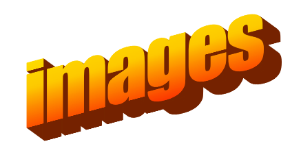

HTML elements can be used, such as the line break (hr) element.

# You Can

## Also Control

### The Size of

#### Your

##### Text…

*But you probably won’t want to do it like that…*

Below is a quick example of an embedded visualization using ggplot2.

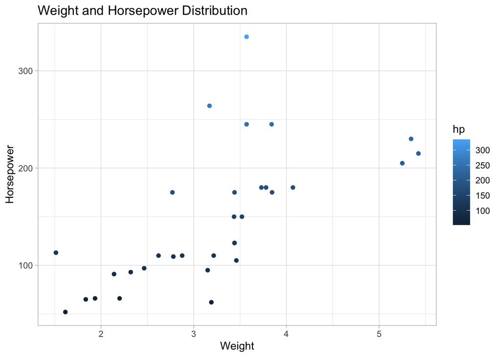

```r
ggplot(mtcars, aes(wt, hp, col=hp)) +
  geom_point() +
  labs(title="Weight and Horsepower Distribution", x="Weight", y="Horsepower") +
  theme_light()
```

And here is a video of a cat being cute.

[video not shown]

## Conclusion

R-markdown is a powerful and versatile tool for sharing your work with others in the R community. I enjoyed playing around with it this week, and look forward to learning about Shiny Apps in Module 13.

As always, the files for this module can be found on my [GitHub Page](https://github.com/gfoster4/LIS5937).